# Public health and economic problems caused by Storms and other severe weather events

## Synopsis

Storms and other severe weather events can cause both public health and economic problems for communities and municipalities. Many severe events can result in fatalities, injuries, and property damage, and preventing such outcomes to the extent possible is a key concern.

This assignment explores the effect of events between 1950 and 2011 from the US NOAA storm database and answering the following questions: * Across the United States, which types of events (as indicated in the EVTYPE variable) are most harmful with respect to population health?  
* Across the United States, which types of events have the greatest economic consequences?

## Data Processing

Load the needed libraries and unzip the file with data.

```r
library(R.utils)
library(ggplot2)
library(plyr)
library(reshape2)

bunzip2("repdata-data-StormData.csv.bz2")
```

Load the data.

```r
storm.data <- read.csv("repdata-data-StormData.csv", stringsAsFactors=FALSE)

storm.data <- data.frame(as.Date(storm.data$BGN_DATE, "%m/%d/%Y %H:%M:%S"),
                     storm.data$EVTYPE,
                     storm.data$FATALITIES,
                     storm.data$INJURIES,
                     storm.data$PROPDMG,
                     as.character(storm.data$PROPDMGEXP),
                     storm.data$CROPDMG,
                     as.character(storm.data$CROPDMGEXP),
                     storm.data$REFNUM)
colnames(storm.data) <- c("BGN_DATE", "EVTYPE", "FATALITIES", "INJURIES",
                          "PROPDMG", "PROPDMGEXP", "CROPDMG", "CROPDMGEXP","REFNUM")
```

```r
# Removing scientific notation
options(scipen=999)

# Mapping exponents
text.values <- c("h","H","k","K","m","M","b","B")
exp.values <- c(10^2,10^2,10^3,10^3,10^6,10^6,10^9,10^9)
map.exponents <- data.frame(text.values, exp.values)

#Adding and calculating cash values
storm.data <- merge(map.exponents, storm.data,
                    by.x="text.values", by.y="PROPDMGEXP", all.y=TRUE)
names(storm.data)[2] <- "prop.exponents"
storm.data$PROPCASH <- storm.data$PROPDMG * storm.data$prop.exponents
storm.data$PROPCASH[is.na(storm.data$PROPCASH)] <- 0

storm.data <- merge(map.exponents, storm.data[,2:11],
                    by.x="text.values", by.y="CROPDMGEXP", all.y=TRUE)
names(storm.data)[2] <- "crop.exponents"
storm.data$CROPCASH <- storm.data$CROPDMG * storm.data$crop.exponents
storm.data$CROPCASH[is.na(storm.data$CROPCASH)] <- 0

storm.data$TOTCASH <- storm.data$PROPCASH + storm.data$CROPCASH

#cleaning data frame
storm.data <- storm.data[,c(4:7,10:13)]
```

## Most harmful types of events with respect to population health across the United States

Summarizing data about fatalities and injuries by type of event and creating a total data frame.

```r
fatalities.total <- ddply(storm.data,.(EVTYPE),summarize,FATALITIES=sum(FATALITIES, na.rm=TRUE))
injuries.total <- ddply(storm.data,.(EVTYPE),summarize,INJURIES=sum(INJURIES, na.rm=TRUE))

total <- merge(fatalities.total, injuries.total,
                    by.x="EVTYPE", by.y="EVTYPE", all=TRUE)
```

Filtering only those that are greater than 99th percentile. Reshaping the data, and draw the graph.

```r
total <- total[total$FATALITIES > quantile(total$FATALITIES, probs=0.99) |
                    total$INJURIES > quantile(total$INJURIES, probs=0.99),]

summary <- melt(total, id=c("EVTYPE"), measure.vars=c("FATALITIES","INJURIES"))
```

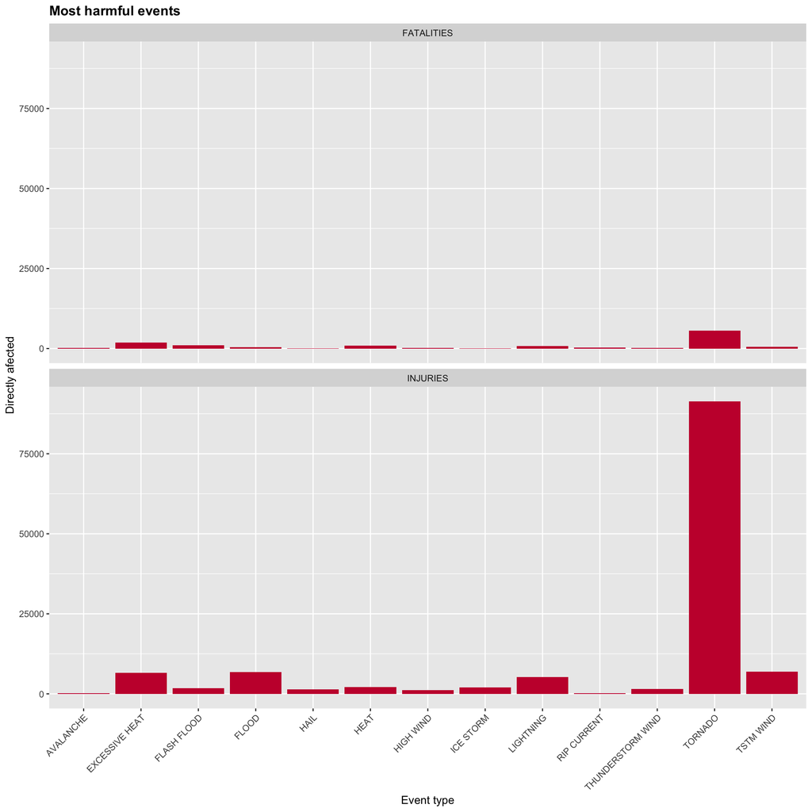

```r
g <- ggplot(summary,
            aes(x=EVTYPE,
                y=value)) + geom_bar(fill="#C70039", stat="identity") +
                            labs(x = "Event type") +
                            labs(y = "Directly afected") +
                            labs(title="Most harmful events") +
                            facet_wrap( ~ variable, ncol=1) +
                            theme(plot.title = element_text(lineheight=.8, face="bold"),
               axis.text.x=element_text(angle=45,vjust=1,hjust=1))
print(g)
```

## Costliers types of events across the United States

Filtering the costliers types of events, taking greater than 99th percentile.

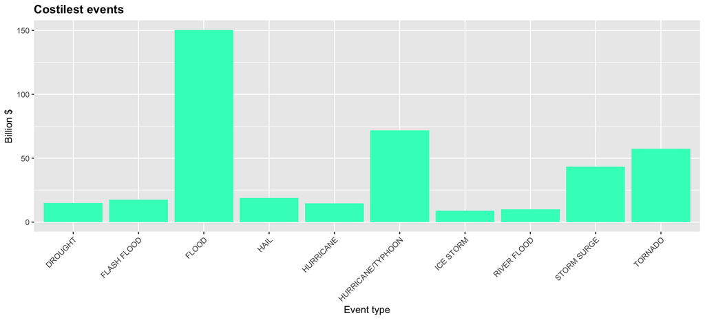

```r
economic.total <- ddply(storm.data,.(EVTYPE),summarize,TOTCASH=sum(TOTCASH, na.rm=TRUE))

g <- ggplot(economic.total[economic.total$TOTCASH > quantile(economic.total$TOTCASH, probs=0.99),],
            aes(x=EVTYPE,
                y=TOTCASH/10^9)) + geom_bar(fill="#33FFC4", stat="identity") +
                                    labs(x = "Event type") +
                                    labs(y = "Billion $") +
                                    labs(title="Costilest events") +
                                    theme(plot.title = element_text(lineheight=.8, face="bold"),
                            axis.text.x=element_text(angle=45,vjust=1,hjust=1))
print(g)
```